# Climate Change

2020-09-04

# 1 Climate change and temperature anomalies

To study climate change, we have used data on the *Combined Land-Surface Air and Sea-Surface Water Temperature Anomalies* in the Northern Hemisphere from [NASA’s Goddard Institute for Space Studies](https://data.giss.nasa.gov/gistemp).

The base period to calculate changes is taken as 1951-1980.While loading the data, `skip` and `na` are used to remove the first row and missing values respectively:

```r
weather <-
  read_csv("https://data.giss.nasa.gov/gistemp/tabledata_v3/NH.Ts+dSST.csv",
           skip = 1,
           na = "***")
```

We’ve converted the dataframe from wide to ‘long’ format and defined variables month as `month`, and the temperature deviation values as `delta`.

```r
glimpse(weather)
```

```
## Rows: 140
## Columns: 19
## $ Year  <dbl> 1880, 1881, 1882, 1883, 1884, 1885, 1886, 1887, 1888, 1889, 189…
## $ Jan   <dbl> -0.54, -0.19, 0.22, -0.59, -0.23, -1.00, -0.68, -1.07, -0.53, -…
## $ Feb   <dbl> -0.38, -0.25, 0.22, -0.67, -0.11, -0.37, -0.68, -0.58, -0.59, 0…
## $ Mar   <dbl> -0.26, 0.02, 0.00, -0.16, -0.65, -0.21, -0.57, -0.36, -0.58, 0.…
## $ Apr   <dbl> -0.37, -0.02, -0.36, -0.27, -0.62, -0.53, -0.34, -0.42, -0.24, …
## $ May   <dbl> -0.11, -0.06, -0.32, -0.32, -0.42, -0.55, -0.34, -0.27, -0.16, …
## $ Jun   <dbl> -0.22, -0.36, -0.38, -0.26, -0.52, -0.47, -0.43, -0.20, -0.04, …
## $ Jul   <dbl> -0.23, -0.06, -0.37, -0.09, -0.48, -0.39, -0.20, -0.23, 0.04, -…
## $ Aug   <dbl> -0.24, -0.03, -0.14, -0.26, -0.50, -0.44, -0.47, -0.52, -0.19, …
## $ Sep   <dbl> -0.26, -0.23, -0.17, -0.33, -0.45, -0.32, -0.34, -0.17, -0.12, …
## $ Oct   <dbl> -0.32, -0.40, -0.53, -0.21, -0.41, -0.30, -0.31, -0.40, 0.04, -…
## $ Nov   <dbl> -0.37, -0.42, -0.32, -0.40, -0.48, -0.28, -0.45, -0.19, -0.03, …
## $ Dec   <dbl> -0.48, -0.28, -0.42, -0.25, -0.40, 0.00, -0.17, -0.43, -0.26, -…
## $ `J-D` <dbl> -0.32, -0.19, -0.21, -0.32, -0.44, -0.40, -0.42, -0.40, -0.22, …
## $ `D-N` <dbl> NA, -0.21, -0.20, -0.33, -0.43, -0.44, -0.40, -0.38, -0.24, -0.…
## $ DJF   <dbl> NA, -0.31, 0.06, -0.56, -0.20, -0.59, -0.45, -0.61, -0.52, -0.0…
## $ MAM   <dbl> -0.24, -0.02, -0.22, -0.25, -0.56, -0.43, -0.42, -0.35, -0.33, …
## $ JJA   <dbl> -0.23, -0.15, -0.30, -0.20, -0.50, -0.44, -0.37, -0.32, -0.06, …
## $ SON   <dbl> -0.32, -0.35, -0.34, -0.32, -0.44, -0.30, -0.37, -0.25, -0.04, …
```

```r
## convert df from wide to long, creating a "Month" and a "Delta" variable

tidyweather <- weather %>% select(1:13) %>% pivot_longer(cols = 2:13, names_to = "month", values_to = "delta")
tidyweather %>% kbl() %>% kable_styling()
```

[output not shown]

[output cut: 1650 more lines]

Let us plot the data using a time-series scatter plot, and add a trendline. To do that, we first need to create a new variable called `date` in order to ensure that the `delta` values are plot chronologically.

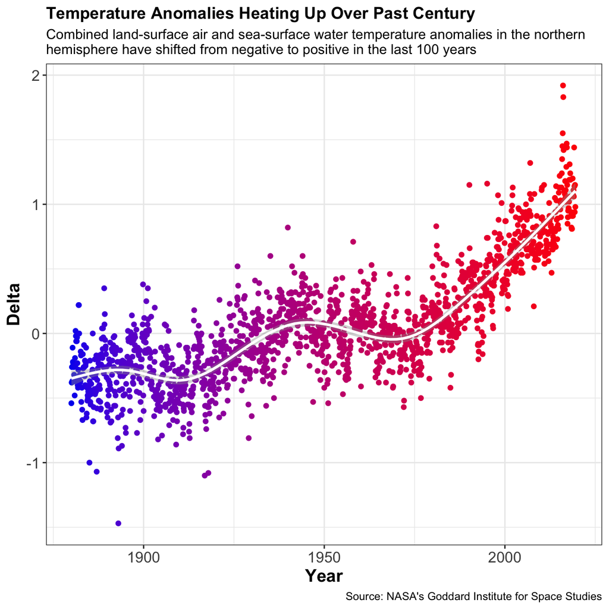

```r
tidyweather <- tidyweather %>%
  mutate(date = ymd(paste(as.character(Year), month, "1")),
         month = month(date),
         year = year(date))

ggplot(tidyweather, aes(x=date, y = delta, colour = date)) +
  geom_point() +
  geom_smooth(color="white") +
  theme(plot.title = element_text(face = "bold", size = 18)) +
  theme_bw() +
  scale_colour_gradient(low="blue2", high="red") +
  labs (
    title = "Temperature Anomalies Heating Up Over Past Century",
  subtitle = "Combined land-surface air and sea-surface water temperature anomalies in the northern \nhemisphere have shifted from negative to positive in the last 100 years", x = "Year", y = "Delta", caption = "Source: NASA's Goddard Institute for Space Studies") +
  theme(legend.position = "none", plot.title = element_text(face = "bold"), axis.text=element_text(size=12),
        axis.title=element_text(size=14,face="bold"))
```

On analysing the temperature difference through different months, we find that the effects of increasing temperature appear to be homogeneous throughout different months.

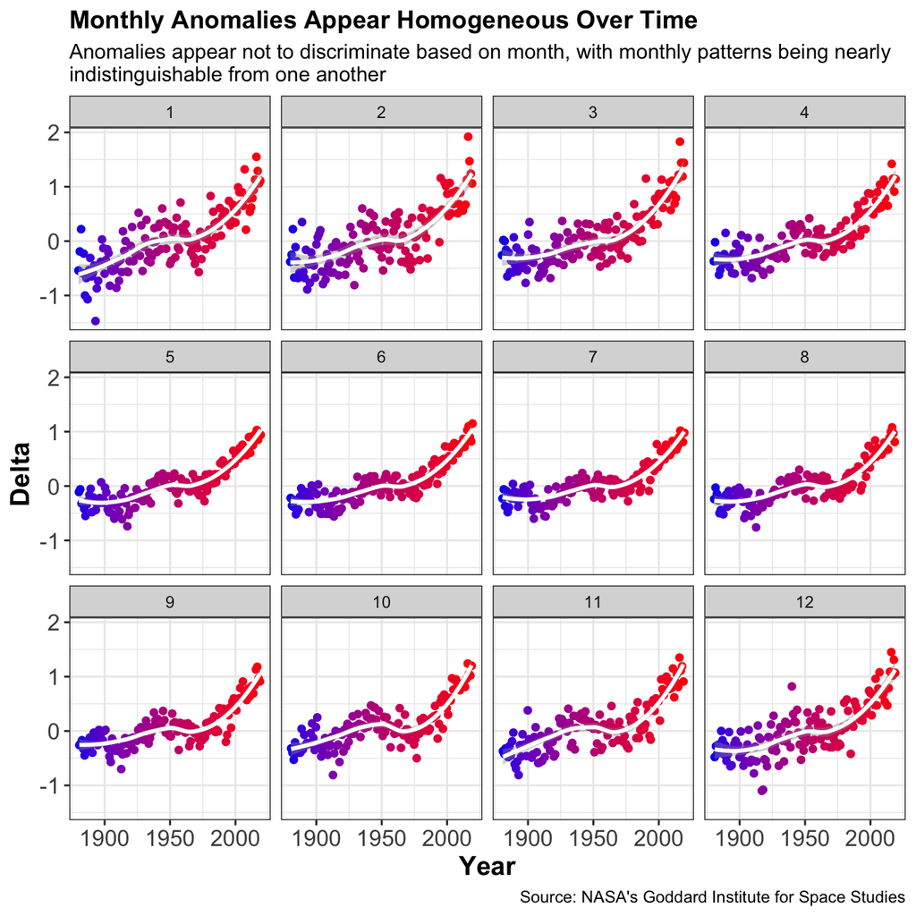

```r
## add to the title/sub , can i thin the smoothing line? , make the theme prettier (no grey months)
ggplot(tidyweather, aes(x=date, y = delta, colour = date))+
  geom_point()+
  geom_smooth(color="white") +
  theme_bw() +
  scale_colour_gradient(low="blue2", high="red") +
  labs (
    title = "Monthly Anomalies Appear Homogeneous Over Time ",
  subtitle = "Anomalies appear not to discriminate based on month, with monthly patterns being nearly \nindistinguishable from one another", x = "Year", y = "Delta", caption = "Source: NASA's Goddard Institute for Space Studies") +
  facet_wrap(~month) +
  theme(legend.position = "none", plot.title = element_text(face = "bold"), axis.text=element_text(size=12),
        axis.title=element_text(size=14,face="bold"))
```

Here, the years are divided into intervals to help study the data better:

```r
comparison <- tidyweather %>%
  filter(year>= 1881) %>%     #remove years prior to 1881
  #create new variable 'interval', and assign values based on criteria below:
  mutate(interval = case_when(
    Year %in% c(1881:1920) ~ "1881-1920",
    Year %in% c(1921:1950) ~ "1921-1950",
    Year %in% c(1951:1980) ~ "1951-1980",
    Year %in% c(1981:2010) ~ "1981-2010",
    TRUE ~ "2011-present"
  ))
```

Now that we have the `interval` variable, we can create a density plot to study the distribution of monthly deviations (`delta`), grouped by the different time periods we are interested in. Set `fill` to `interval` to group and colour the data by different time periods.

```r
## fix the colors
ggplot(comparison, aes(x=delta, fill=interval, colour = interval))+

  #density plot with tranparency set to 20%

  geom_density(alpha=0.2) +
  theme_bw() +
  labs(
    title = "Density Plot for Monthly Temperature Anomalies",
    subtitle = "A clear increase in temperature anomalies shown through time periods \nfrom 1881 to present day",
    x = "Delta",
    y     = "Density",
    caption = "Source: NASA's Goddard Institute for Space Studies")  +
  scale_fill_manual(values = c("blue2", "darkorchid4", "purple1", "red1", "red"))  +
  scale_color_manual(values = c("blue2", "darkorchid4", "purple1", "red1", "red")) +
  theme(plot.title = element_text(face = "bold"), axis.text=element_text(size=12),
        axis.title=element_text(size=14,face="bold"))+
  guides(color=guide_legend("Time Period"),fill=guide_legend("Time Period"))
```

[output not shown]

So far, we have been working with monthly anomalies. However, we might be interested in average annual anomalies. We can do this by using `group_by()` and `summarise()`, followed by a scatter plot to display the result.

```r
#creating yearly averages
average_annual_anomaly <- tidyweather %>%
  group_by(year) %>%   #grouping data by Year

  # creating summaries for mean delta
  # use `na.rm=TRUE` to eliminate NA (not available) values
  summarise(annual_average_anomaly = mean(delta, na.rm=TRUE))

#plotting the data:
ggplot(average_annual_anomaly, aes(x=year, y= annual_average_anomaly, colour = year))+
  geom_point()+

  #Fit the best fit line, using LOESS method
  geom_smooth(colour = "white") +

  #change to theme_bw() to have white background + black frame around plot
  theme_bw() +

    ## add color gradient
  scale_colour_gradient(low="blue2", high="red") +

  labs (
    title = "Average Yearly Temperature Anomaly Signifies Steep Temperature Increase in Past 50 Years",
    subtitle = "Yearly temperature anomaly has accelerated significantly in more recent years, raising concern among climate scientists",
    y = "Average Annual Delta",
    x = "Year",
    caption = "Source: NASA's Goddard Institute for Space Studies")  +

  theme(legend.position = "none", plot.title = element_text(face = "bold"), axis.text=element_text(size=12),
        axis.title=element_text(size=14,face="bold"))
## make more clear
```

[output not shown]